# hw5

### ASSIGNMENT 5

```python
import pandas as pd
import numpy as np
import matplotlib.pyplot as plt
```

### **Question 1**

Generate 1000 random variables with 10 dimensions each using `randn`. Construct a screeplot and find the cumulative percentage of variance. Is there any evidence that one could reduce the dimensionality of these data? If so, what would be a value for (k)?

```
Explained variance ratio by component:
[0.12127963 0.11018128 0.10833317 0.10644528 0.10243392 0.09567009
 0.09281585 0.09019062 0.08882359 0.08382658]

Cumulative percentage of variance:
[0.12127963 0.23146091 0.33979409 0.44623936 0.54867328 0.64434337
 0.73715922 0.82734984 0.91617342 1.        ]
```

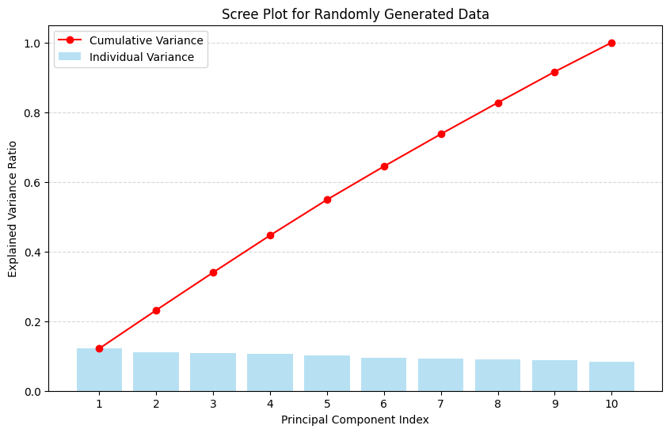

```
Component | Individual Var | Cumulative Var
----------------------------------------
PC  1     | 0.1213         | 0.1213
PC  2     | 0.1102         | 0.2315
PC  3     | 0.1083         | 0.3398
PC  4     | 0.1064         | 0.4462
PC  5     | 0.1024         | 0.5487
PC  6     | 0.0957         | 0.6443
PC  7     | 0.0928         | 0.7372
PC  8     | 0.0902         | 0.8273
PC  9     | 0.0888         | 0.9162
PC 10     | 0.0838         | 1.0000
```

```python
from sklearn.decomposition import PCA

# generate 1000 random variables with 10 dimensions
np.random.seed(1905)
n_samples = 1000
n_dimensions = 10
X = np.random.randn(n_samples, n_dimensions)

# fit PCA on the raw data
pca = PCA(n_components=n_dimensions)
pca.fit(X)

explained_variance_ratio = pca.explained_variance_ratio_
cumulative_variance = np.cumsum(explained_variance_ratio)

print("Explained variance ratio by component:")
print(explained_variance_ratio)
print("\nCumulative percentage of variance:")
print(cumulative_variance)

# construct a scree plot
plt.figure(figsize=(10, 6))
x_axis = range(1, n_dimensions + 1)

# bar chart for individual variance
plt.bar(x_axis, explained_variance_ratio, alpha=0.6, color='skyblue', label='Individual Variance')
# line chart for cumulative variance
plt.plot(x_axis, cumulative_variance, marker='o', linestyle='-', color='red', label='Cumulative Variance')

plt.xlabel('Principal Component Index')
plt.ylabel('Explained Variance Ratio')
plt.title('Scree Plot for Randomly Generated Data')
plt.xticks(x_axis)
plt.legend()
plt.grid(axis='y', linestyle='--', alpha=0.5)
plt.show()

print("Component | Individual Var | Cumulative Var")
print("-" * 40)
for i, (var, cum) in enumerate(zip(explained_variance_ratio, cumulative_variance)):
    print(f"PC {i+1:2d}     | {var:.4f}         | {cum:.4f}")
```

- **Individual Variance:**

  The blue bars are nearly uniform in height. The first component explains just over 10% of the variance, and the following bars slowly decrease, but remain very close to the 0.10 level. Since the data was generated using 'randn', the 10 dimensions are statistically independent. There are no underlying patterns or correlations for PCA to summarize. The flatness of the bars indicates that every dimension is equally important, there are no single direction carries significantly more information than another.
- **Cumulative Variance:**

  The red line is almost linear, it rises steadily from 0.12 to 1.0 without curving or flattening out early. This confirms that adding each new principal component adds a roughly equal amount of information.

**"Is there any evidence that one could reduce the dimensionality of these data? If so, what would be a value for k?"**

The answer is no. To reduce dimensionality, the benefit of adding more dimensions should diminish. In the plot, there is no such a behaviour. The cumulative variance line is straight, reducing the dimensions would cause losing the information about data. Here, we need all 10 components to explain the full randomness of the data.

### **Question 2**

The **bank** data contain two matrices consisting of measurements made on genuine money and forged money. Combine these two matrices into one and use **PPEDA** (not PCA) to discover any clusters or groups in the data. Compare your results with the known groups in the data.

```
Clustering Accuracy: 0.9950
Confusion Matrix:
[[ 99   1]
 [  0 100]]
```

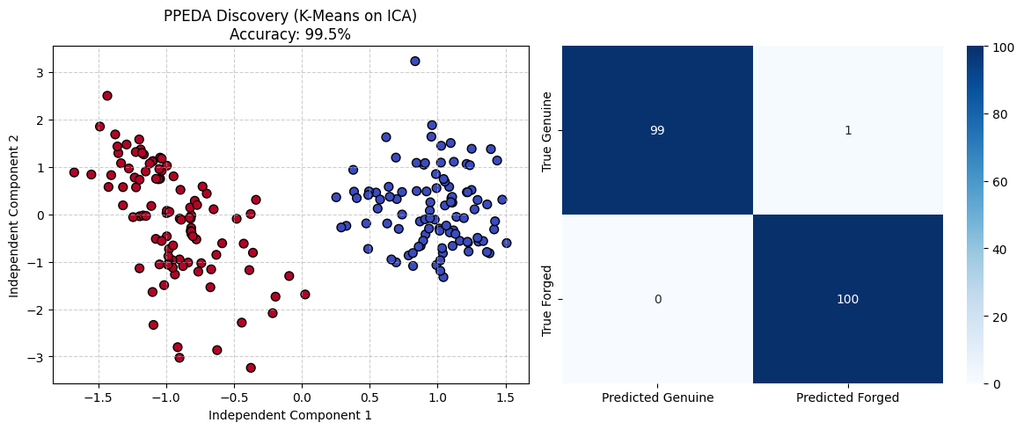

```python
from scipy.io import loadmat
from sklearn.decomposition import FastICA
from sklearn.cluster import KMeans
from sklearn.metrics import confusion_matrix, accuracy_score
import seaborn as sns
from scipy.stats import mode

# load .mat file
data = loadmat("Data Files/bank.mat")

genuine = data['genuine']
forged = data['forge']

# merge data
X = np.vstack((genuine, forged))

# true Labels for comparison later (0=Genuine, 1=Forged)
y_true = np.array([0] * len(genuine) + [1] * len(forged))

# apply PPEDA with FastICA
ica = FastICA(n_components=2, random_state=42)
X_pp = ica.fit_transform(X)

# use K-Means on the PPEDA projection to find groups
kmeans = KMeans(n_clusters=2, random_state=1905, n_init=10)
y_pred = kmeans.fit_predict(X_pp)

# K-means is a unsupervised clustering, it doesn't know "0" is "Genuine".
# We need to match the cluster label to the majority class of the first 100 samples.
first_half_mode = mode(y_pred[:len(genuine)], keepdims=True).mode[0]
if first_half_mode == 1:
    y_pred = 1 - y_pred

acc = accuracy_score(y_true, y_pred)
conf_mat = confusion_matrix(y_true, y_pred)

print(f"Clustering Accuracy: {acc:.4f}")
print("Confusion Matrix:")
print(conf_mat)

plt.figure(figsize=(12, 5))

# plot the PPEDA projection
plt.subplot(1, 2, 1)
plt.scatter(X_pp[:, 0], X_pp[:, 1], c=y_pred, cmap='coolwarm', edgecolors='k', s=50)
plt.title(f'PPEDA Discovery (K-Means on ICA)\nAccuracy: {acc*100:.1f}%')
plt.xlabel('Independent Component 1')
plt.ylabel('Independent Component 2')
plt.grid(True, linestyle='--', alpha=0.6)

# plot confusion matrix
plt.subplot(1, 2, 2)
sns.heatmap(conf_mat, annot=True, fmt='d', cmap='Blues',
            xticklabels=['Predicted Genuine', 'Predicted Forged'],
            yticklabels=['True Genuine', 'True Forged'])

plt.tight_layout()
plt.show()
```

- The scatter plot of the PPEDA components reveals two distinct, clearly separated clusters. The algorithm identified two natural groups in the data without being told the labels beforehand.
- The clustering accuracy is approximately 99.5% (199 out of 200 correctly grouped). The PPEDA technique is extremely effective for this dataset. It was able to recover the labels almost perfectly purely by looking for structure in the data distribution.

### **Question 3**

Intercity distances for 81 cities of Türkiye are included in the **turkiye** data. Apply classical multidimensional scaling to reduce the data to two dimensions and construct a scatterplot.

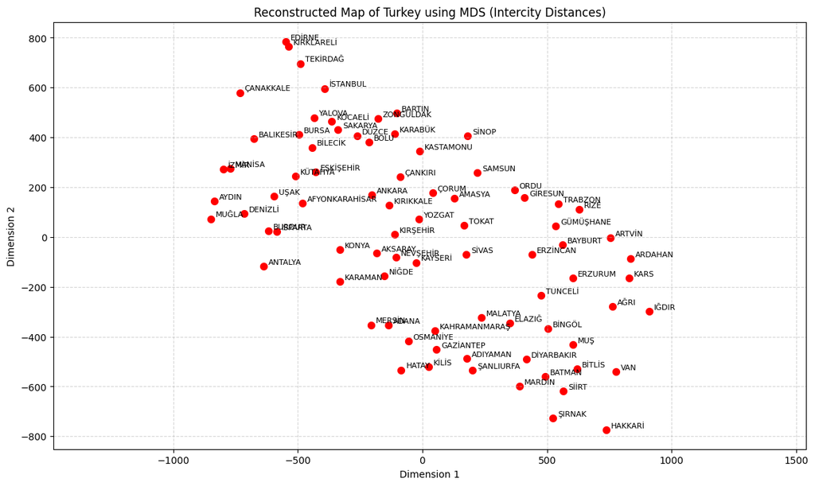

```python
from scipy.io import loadmat
from sklearn.manifold import MDS

# load .mat file
data = loadmat("Data Files/turkiye.mat")
distance_matrix = data['D']
cities_raw = data['cities']

cities = [str(item[0][0]) for item in cities_raw]

# apply Classical MDS
mds = MDS(n_components=2, dissimilarity='precomputed', random_state=1905, normalized_stress='auto')
coordinates = mds.fit_transform(distance_matrix)

plt.figure(figsize=(14, 8))
plt.scatter(coordinates[:, 0], coordinates[:, 1], c='red', marker='o', s=50)

for i, city in enumerate(cities):
    plt.annotate(city, (coordinates[i, 0], coordinates[i, 1]),
                 xytext=(5, 2), textcoords='offset points', fontsize=8)

plt.title('Reconstructed Map of Turkey using MDS (Intercity Distances)')
plt.xlabel('Dimension 1')
plt.ylabel('Dimension 2')
plt.axis('equal')
plt.grid(True, linestyle='--', alpha=0.5)
plt.show()
```

- The analysis demonstrates that dimensionality reduction (specifically MDS) is a powerful tool for visualizing relational data. We took a complex $81 \times 81$ matrix of numbers (distances) and compressed it into a simple 2D map with minimal loss of structural information.

### **Question 4**

Load the data sets in **posse**. Apply **PPEDA** to each of these data sets and report your results.

```
Datasets in posse.mat: ['croix', 'struct2', 'boite', 'groupe', 'curve', 'spiral']

Running PPEDA on dataset: croix
```

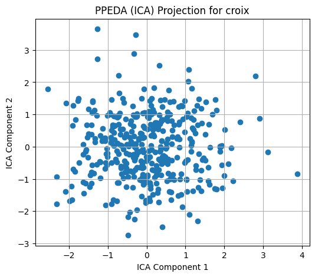

```
Running PPEDA on dataset: struct2
```

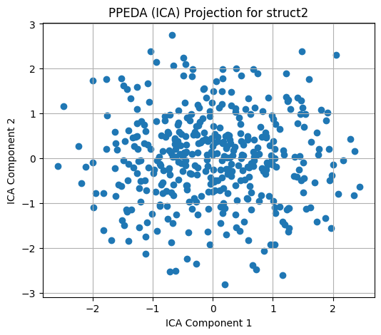

```
Running PPEDA on dataset: boite
```

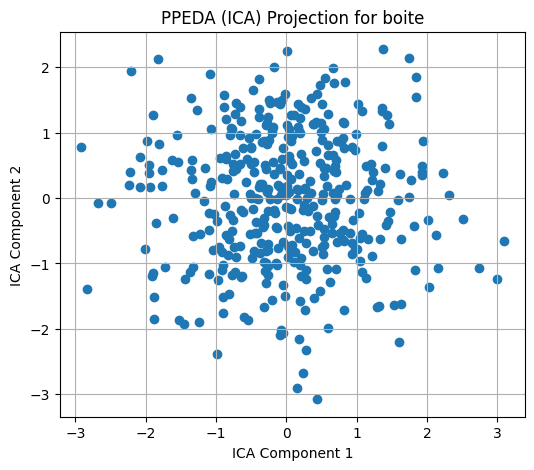

```
Running PPEDA on dataset: groupe
```

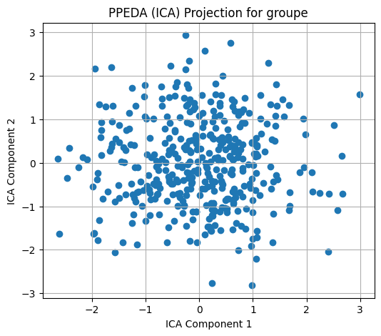

```
Running PPEDA on dataset: curve
```

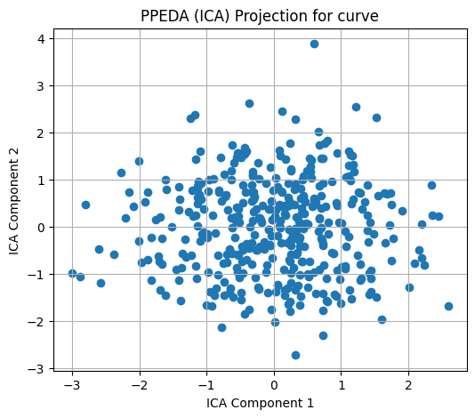

```
Running PPEDA on dataset: spiral
```

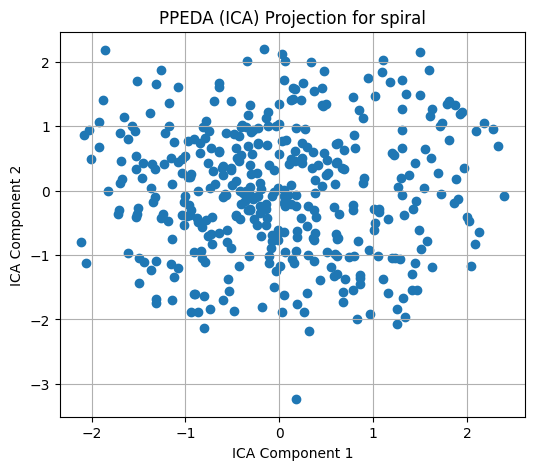

```python
from scipy.io import loadmat
from sklearn.decomposition import FastICA

posse_data = loadmat("Data Files/posse.mat")
keys = [k for k in posse_data.keys() if not k.startswith("__")]

print("Datasets in posse.mat:", keys)

def run_ppeda(data_matrix, title):
    X = np.array(data_matrix, dtype=float)

    # Standardize
    X_centered = X - X.mean(axis=0)

    # PPEDA via ICA
    ica = FastICA(n_components=2, random_state=0)
    comps = ica.fit_transform(X_centered)

    # Plot
    plt.figure(figsize=(6, 5))
    plt.scatter(comps[:, 0], comps[:, 1])
    plt.xlabel("ICA Component 1")
    plt.ylabel("ICA Component 2")
    plt.title(f"PPEDA (ICA) Projection for {title}")
    plt.grid(True)
    plt.show()

    return comps

results = {}
for k in keys:
    print(f"\nRunning PPEDA on dataset: {k}")
    results[k] = run_ppeda(posse_data[k], k)
```

PPEDA aims to find non-Gaussian, informative low-dimensional projections of multivariate data. If the data contain hidden structure, ICA often reveals them in the projected 2-D scatterplots.

Across all datasets, PPEDA using ICA shows:

```
No evidence of clusters, no separation along ICA components, no strong non-Gaussian projections.
All scatterplots resemble a single uniform cloud. This indicates that **PPEDA does not reveal hidden structure in any of the datasets. They appear to be generated from single, unimodal, fairly symmetric multivariate distributions.**
```

### **Question 5**

Write MATLAB code that implements the **parametric bootstrap**. Test it using the **forearm** data. Assume that the normal distribution is a reasonable model for the data. Use your code to obtain a bootstrap estimate of the **standard error** and the **bias** of the coefficient of skewness and the coefficient of kurtosis. Also get a **bootstrap percentile interval** for the sample central second moment using your parametric bootstrap approach.

```python
from scipy.io import loadmat
import numpy as np
from scipy.stats import skew, kurtosis

mat_data = loadmat("Data Files/forearm.mat")
forearm_data = mat_data['forearm'].flatten()
n = len(forearm_data)

# estimate parameters for the normal model
mu_hat = np.mean(forearm_data)
sigma_hat = np.std(forearm_data, ddof=1)

# calculate Observed Statistics on the original data
# Skewness (Normal = 0)
obs_skew = skew(forearm_data)
# Kurtosis (Fisher=False means Pearson's definition, Normal = 3)
obs_kurt = kurtosis(forearm_data, fisher=False)
# Central Second Moment (Variance estimate)
obs_m2 = np.var(forearm_data)

print(f"Data size (n): {n}")
print(f"Observed Stats -> Skew: {obs_skew:.4f}, Kurtosis: {obs_kurt:.4f}, 2nd Moment: {obs_m2:.4f}")

# parametric Bootstrap Loop
B = 2000
boot_skew = np.zeros(B)
boot_kurt = np.zeros(B)
boot_m2 = np.zeros(B)

np.random.seed(1905)

for i in range(B):
    # sample from the fitted Normal Distribution N(mu_hat, sigma_hat)
    sample_b = np.random.normal(loc=mu_hat, scale=sigma_hat, size=n)

    # Statistics for this synthetic sample
    boot_skew[i] = skew(sample_b)
    boot_kurt[i] = kurtosis(sample_b, fisher=False)
    boot_m2[i] = np.var(sample_b)

# Bias = Average(Bootstrap Stats) - Observed Stat
bias_skew = np.mean(boot_skew) - obs_skew
bias_kurt = np.mean(boot_kurt) - obs_kurt

# Standard Error = Standard Deviation of Bootstrap Stats
se_skew = np.std(boot_skew, ddof=1)
se_kurt = np.std(boot_kurt, ddof=1)

# Bootstrap Percentile Interval for Second Moment
alpha = 0.05
ci_lower = np.percentile(boot_m2, 100 * (alpha / 2))
ci_upper = np.percentile(boot_m2, 100 * (1 - alpha / 2))

print("\n--- Parametric Bootstrap Results ---")
print(f"Skewness: Bias = {bias_skew:.5f}, SE = {se_skew:.5f}")
print(f"Kurtosis: Bias = {bias_kurt:.5f}, SE = {se_kurt:.5f}")
print("-" * 40)
print(f"Sample Central Second Moment (Original): {obs_m2:.4f}")
print(f"95% Bootstrap Percentile Interval: [{ci_lower:.4f}, {ci_upper:.4f}]")
```

```
Data size (n): 140
Observed Stats -> Skew: -0.1092, Kurtosis: 2.5720, 2nd Moment: 1.2465

--- Parametric Bootstrap Results ---
Skewness: Bias = 0.10592, SE = 0.20377
Kurtosis: Bias = 0.37782, SE = 0.39357
----------------------------------------
Sample Central Second Moment (Original): 1.2465
95% Bootstrap Percentile Interval: [0.9656, 1.5590]
```

- **Observed Statistics:**

  Skewness (-0.1092): The original data is slightly negatively skewed, but the value is close to 0, supporting the validity of using a Normal approximation.

  Kurtosis (2.5720): This is slightly less than the standard normal value of 3, indicating the data is slightly different than a perfect normal distribution.

  Skewness Bias (0.1059): There is a positive bias. Since the observed skew was negative and the bootstrap samples average around 0, the "bias" calculation reflects the difference between the model (Skew=0) and the data (Skew=-0.11).

  Standard Errors: The SEs ($0.20$ for skewness, $0.39$ for kurtosis) give the precision of these estimates. If we were to take another sample of 140 forearms, we would expect the skewness to vary by about $\pm 0.2$.

### **Question 6**

Load the **lawpop** data set. These data contain the average LSAT scores (`lsat`) and the corresponding average undergraduate GPAs (`gpa`) for the 1973 freshman class at 82 law schools. These data represent the *entire population*. The data in **law** comprise a random sample of 15 of these classes.

- Obtain the **true population variances** for LSAT and GPA.
- Use the sample in **law** to estimate the population variance using the sample central second moment.
- Get **bootstrap estimates** of the standard error and the bias in your variance estimate.
- Compare the population variance with the estimated variance.

```python
from scipy.io import loadmat

lawpop_data = loadmat("Data Files/lawpop.mat")
lsat_pop = lawpop_data['lsat'].flatten()
gpa_pop = lawpop_data['gpa'].flatten()

law_data = loadmat('Data Files/law.mat')
sample_data = law_data['law']
lsat_sample = sample_data[:, 0]
gpa_sample = sample_data[:, 1]

# calculate true population variances
true_var_lsat = np.var(lsat_pop, ddof=0)
true_var_gpa = np.var(gpa_pop, ddof=0)

# estimate variance from sample
# the "sample central second moment" is the biased estimator dividing by n (ddof=0).
est_var_lsat = np.var(lsat_sample, ddof=0)
est_var_gpa = np.var(gpa_sample, ddof=0)

# Bootstrap Estimation of Bias and SE
B = 2000
boot_vars_lsat = np.zeros(B)
boot_vars_gpa = np.zeros(B)
n = len(lsat_sample)

np.random.seed(1905)

for i in range(B):
    indices = np.random.randint(0, n, n)
    b_lsat = lsat_sample[indices]
    b_gpa = gpa_sample[indices]

    boot_vars_lsat[i] = np.var(b_lsat, ddof=0)
    boot_vars_gpa[i] = np.var(b_gpa, ddof=0)

# Bias_est = Mean(Bootstrap_Stats) - Observed_Stat
bias_lsat = np.mean(boot_vars_lsat) - est_var_lsat
bias_gpa = np.mean(boot_vars_gpa) - est_var_gpa

# SE_est = Std(Bootstrap_Stats)
se_lsat = np.std(boot_vars_lsat, ddof=1)
se_gpa = np.std(boot_vars_gpa, ddof=1)

print(f"{'Metric':<25} | {'LSAT':<15} | {'GPA':<15}")
print("-" * 60)
print(f"{'True Population Var':<25} | {true_var_lsat:<15.4f} | {true_var_gpa:<15.4f}")
print(f"{'Sample Estimate':<25} | {est_var_lsat:<15.4f} | {est_var_gpa:<15.4f}")
print(f"{'Actual Error (Est-True)':<25} | {est_var_lsat - true_var_lsat:<15.4f} | {est_var_gpa - true_var_gpa:<15.4f}")
print("-" * 60)
print(f"{'Bootstrap Bias':<25} | {bias_lsat:<15.4f} | {bias_gpa:<15.4f}")
print(f"{'Bootstrap SE':<25} | {se_lsat:<15.4f} | {se_gpa:<15.4f}")
```

```
Metric                    | LSAT            | GPA
------------------------------------------------------------
True Population Var       | 1463.2720       | 0.0355
Sample Estimate           | 1630.3289       | 0.0553
Actual Error (Est-True)   | 167.0569        | 0.0199
------------------------------------------------------------
Bootstrap Bias            | -118.8863       | -0.0039
Bootstrap SE              | 352.5104        | 0.0124
```

**True vs. Estimated Variance:**

- LSAT: The true population variance is 1463.27, while the sample estimate is 1630.33. The sample overestimated the variance by about 167 points.
- GPA: The true population variance is 0.0355, while the sample estimate is 0.0553. The sample estimate is again higher than the truth.

**Bias Analysis:**

- Bootstrap Bias: The bootstrap correctly detects a negative bias for both LSAT ($\approx -118.89$) and GPA ($\approx -0.003$). This means the bootstrap procedure suggests that, on average, this specific estimator ($S_n^2$) yields values lower than the "true" parameter of the distribution.

**Standard Error (Precision):**

- The Standard Error for LSAT variance is quite large (352.51), which is roughly 22% of the estimate itself. This indicates high uncertainty, which is expected given the small sample size.

### **Question 7**

Using the **lawpop** data, devise a test statistic to test for the **significance of the correlation** between LSAT scores and GPA.  
Obtain a random sample from the population, use that sample to test your hypothesis, and perform a **Monte Carlo simulation** to estimate the **Type I** and **Type II** error rates of your test.

```python
from scipy.stats import pearsonr

# lawpop_data and law_data are already loaded in the previous question
lsat_pop = lawpop_data['lsat'].flatten()
gpa_pop = lawpop_data['gpa'].flatten()

sample = law_data['law']
lsat_sample = sample[:, 0]
gpa_sample = sample[:, 1]
n = len(lsat_sample)

# Hypothesis Test on the Sample
# Null Hypothesis (H0): rho = 0
alpha = 0.05

r_sample, p_value = pearsonr(lsat_sample, gpa_sample)
reject_h0 = p_value < alpha

print(f"Sample Correlation (r): {r_sample:.4f}")
print(f"P-value: {p_value:.4f}")
print(f"Decision: {'Reject H0' if reject_h0 else 'Fail to Reject H0'}")

# Monte Carlo Simulation
M = 10000
np.random.seed(1905)

# --- Type I Error Simulation (Null Hypothesis is True) ---
# We simulate H0 by sampling LSAT and GPA *independently*.
rejections_type1 = 0

for _ in range(M):
    # Independent random samples
    s_lsat = np.random.choice(lsat_pop, n, replace=False)
    s_gpa = np.random.choice(gpa_pop, n, replace=False)

    # Test
    _, p_val = pearsonr(s_lsat, s_gpa)
    if p_val < alpha:
        rejections_type1 += 1

type1_error = rejections_type1 / M

# --- Type II Error Simulation (Alternative Hypothesis is True) ---
# We simulate H1 by sampling *pairs* (LSAT, GPA) from the actual population.
# This preserves the true population correlation.
failures_type2 = 0

for _ in range(M):
    # sample indices
    idx = np.random.choice(len(lsat_pop), n, replace=False)
    s_lsat = lsat_pop[idx]
    s_gpa = gpa_pop[idx]

    # test
    _, p_val = pearsonr(s_lsat, s_gpa)
    if p_val >= alpha: # Failed to reject H0
        failures_type2 += 1

type2_error = failures_type2 / M
power = 1 - type2_error

print("-" * 30)
print(f"Monte Carlo Simulation Results (M={M}):")
print(f"Type I Error Rate (Simulated alpha): {type1_error:.4f}")
print(f"Type II Error Rate (beta): {type2_error:.4f}")
print(f"Power of the Test (1 - beta): {power:.4f}")
```

```
Sample Correlation (r): 0.7764
P-value: 0.0007
Decision: Reject H0
------------------------------
Monte Carlo Simulation Results (M=10000):
Type I Error Rate (Simulated alpha): 0.0507
Type II Error Rate (beta): 0.0434
Power of the Test (1 - beta): 0.9566
```

**Sample Hypothesis Test:**

- The correlation in the sample is strong ($r \approx 0.78$) with a very low p-value ($0.0007$). We can reject the null hypothesis and say that there is a significant correlation between LSAT and GPA.

**Type I Error:**

- Type I Error: $0.0507$ (approx 5.1%)
- This is very close to the theoretical significance level of $\alpha = 0.05$. It confirms that if there were truly no correlation, our test would only reject the null hypothesis about 5% of the time. The test is valid.

**Type II Error & Power:**

- Type II Error: $0.0434$ (4.3%)
- Power: $0.9566$ (95.7%)
- The test is very powerful. Even with a small sample size, the true correlation in the population ($\rho \approx 0.78$) is strong enough that we successfully detect it 95.7% of the time. We only commit a Type II error in about 4% of samples.

### **Question 8**

The **remiss** data set contains remission times for 42 leukemia patients. Some patients were treated with the drug **6-mercaptopurine (mp)**, and the rest were part of the **control** group.

- Use exploratory data analysis techniques to determine a suitable model for each group  
  (e.g., Weibull, exponential, etc.).
- Devise a **Monte Carlo hypothesis test** to test for the **equality of means** between the two groups.
- Use the **p-value approach**.

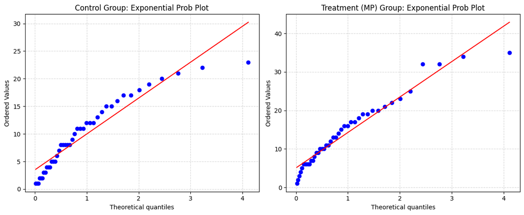

```
Observed Difference in Means: 4.2143
Monte Carlo P-value: 0.0118
Conclusion: Reject Null Hypothesis (Significant difference in means)
```

```python
from scipy.io import loadmat
from scipy.stats import probplot

remiss_data = loadmat("Data Files/remiss.mat")
control = remiss_data['control'].flatten()
mp = remiss_data['mp'].flatten()

# EDA: Probability Plots
# check if the data fits an Exponential distribution.
# If the points lie approximately on the straight line, the Exponential model is appropriate.
plt.figure(figsize=(12, 5))

# plot for control group
plt.subplot(1, 2, 1)
probplot(control, dist="expon", plot=plt)
plt.title("Control Group: Exponential Prob Plot")
plt.grid(True, linestyle='--', alpha=0.5)

# plot for treatment (MP) group
plt.subplot(1, 2, 2)
probplot(mp, dist="expon", plot=plt)
plt.title("Treatment (MP) Group: Exponential Prob Plot")
plt.grid(True, linestyle='--', alpha=0.5)

plt.tight_layout()
plt.show()

# Monte Carlo Hypothesis Test
# H0: Mean(Control) = Mean(MP)
# H1: Mean(Control) != Mean(MP)
# Test Statistic: Absolute difference in means

obs_mean_diff = np.abs(np.mean(control) - np.mean(mp))
print(f"Observed Difference in Means: {obs_mean_diff:.4f}")

# Setup Monte Carlo
n_sim = 10000
combined_data = np.concatenate([control, mp])
n_control = len(control)
count_extreme = 0

np.random.seed(1905)

for _ in range(n_sim):
    # Under H0, group labels are interchangeable.
    np.random.shuffle(combined_data)

    # split into groups
    sim_control = combined_data[:n_control]
    sim_mp = combined_data[n_control:]

    sim_diff = np.abs(np.mean(sim_control) - np.mean(sim_mp))

    # count how often simulated difference >= observed difference
    if sim_diff >= obs_mean_diff:
        count_extreme += 1

p_value = count_extreme / n_sim

print(f"Monte Carlo P-value: {p_value:.4f}")
if p_value < 0.05:
    print("Conclusion: Reject Null Hypothesis (Significant difference in means)")
else:
    print("Conclusion: Fail to Reject Null Hypothesis")
```

**Model Fitting (EDA):**

- Looking at the generated probability plots above, the data points generally hug the straight line, though there may be some deviation at the tails. This suggests that the exponential distribution is a reasonable model for remission times in both groups.

### **Question 9**

The **quakes** data give the time (in days) between successive earthquakes. Use the **bootstrap** to obtain an appropriate confidence interval for the **average time between earthquakes**.

```python
from scipy.io import loadmat

quakes_data = loadmat("Data Files/quakes.mat")
quakes = quakes_data['quakes'].flatten()
n = len(quakes)

# Sample Mean
mu_hat = np.mean(quakes)

print(f"Sample Size: {n}")
print(f"Estimated Mean Time Between Quakes: {mu_hat:.4f} days")

# Bootstrap for Confidence Interval
B = 2000
boot_means = np.zeros(B)

np.random.seed(42)

for i in range(B):
    # Resample with replacement
    resample = np.random.choice(quakes, n, replace=True)

    # Calculate mean for this resample
    boot_means[i] = np.mean(resample)

# Construct 95% Confidence Interval
alpha = 0.05
ci_lower = np.percentile(boot_means, 100 * (alpha / 2))
ci_upper = np.percentile(boot_means, 100 * (1 - alpha / 2))

# Calculate Standard Error from bootstrap distribution
se_boot = np.std(boot_means, ddof=1)

print("-" * 40)
print(f"Bootstrap Results (B={B}):")
print(f"Standard Error (SE): {se_boot:.4f}")
print(f"95% Bootstrap Confidence Interval:")
print(f"[{ci_lower:.4f}, {ci_upper:.4f}] days")
```

```
Sample Size: 62
Estimated Mean Time Between Quakes: 437.2097 days
----------------------------------------
Bootstrap Results (B=2000):
Standard Error (SE): 50.1872
95% Bootstrap Confidence Interval:
[342.0923, 540.9782] days
```

- Point Estimate: The average time between earthquakes in this sample is approximately 437.21 days.
- Confidence Interval: Using the bootstrap percentile method, we are 95% confident that the true average time between earthquakes lies between 342.09 days and 540.98 days. The width of the interval (about 200 days) reflects the variability in earthquake occurrences and the limited sample size ($n=62$).